# PeñaMontenegro_et_al_2020_part_1

**Supporting code used for the paper:**

**Metatranscriptomic analysis reveals responses of deepsea microbial communities to oil and dispersant exposure**

*Tito D. Peña-Montenegro<sup>1,2</sup>, Sara Kleindienst<sup>3</sup>, Andrew E. Allen<sup>4,5</sup>, A. Murat Eren<sup>6,7</sup>, Juan David Sánchez-Calderón<sup>8</sup>, Jonathan Arnold<sup>2,9</sup>, Samantha B. Joye<sup>1,</sup>*</sup>*

```python
# Import libraries

import altair as alt
from altair import datum
from IPython.display import SVG, display
import math
import matplotlib.pyplot as plt
import numpy as np
import os
import pandas as pd
import re
from scipy.optimize import curve_fit
from sklearn.decomposition import PCA
from sklearn.preprocessing import StandardScaler
from sklearn.metrics import r2_score
import statsmodels.api as sm
from statsmodels.stats.outliers_influence import summary_table

%matplotlib inline
alt.renderers.enable('default')
```

```
RendererRegistry.enable('default')
```

**Supplementary Figure 1**

```python
#Loading data

Location = './sk_summary_data.csv'
sk_df = pd.read_csv(Location)
```

```python
#Subset columns and melting table into long format

qc_df=sk_df.loc[:,['sample_id','passed_qc','failed_qc']]
qc_df_longformat = pd.melt(qc_df, id_vars=['sample_id'], var_name='Quality Check', value_name='Reads')

#Generating Plot

figS1A = alt.Chart(qc_df_longformat).mark_bar().encode(
    alt.Color('Quality Check',
        legend=alt.Legend(title='Quality Check'),
        scale=alt.Scale(
            domain=['passed_qc', 'failed_qc'],
            range=['#EFCC00', '#c7c7c7']
        ),
    ),
    alt.X('sample_id:N',
        axis=alt.Axis(title='sample_id'),
    ),
    y='Reads:Q',
)

figS1A
```

[interactive chart not shown]

```python
#Subset columns

rrna_df=sk_df.loc[:,['sample_id','rna_reads','pred_prot_reads','unknown_fun_reads']]
rrna_df.columns=['Treatment','B','C','A']

#melting table into long format

rna_df_longformat = pd.melt(rrna_df, id_vars=['Treatment'], var_name='Quality Check', value_name='Reads')
rrna_df_longformat = pd.melt(rrna_df, id_vars=['Treatment'], var_name='Annotation', value_name='Reads')

#Generating Plot

figS1B = alt.Chart(rrna_df_longformat).mark_bar().encode(
    alt.Color('Annotation:N',
        legend=alt.Legend(title='Predicted Features'),
        scale=alt.Scale(
            domain=['A', 'B', 'C'],
            range=['#c7c7c7', '#EFCC00', '#1f77b4']
        ),
    ),
    alt.X('Treatment:N',
        axis=alt.Axis(title='Treatment'),
           ),
y='Reads', )

#Where A= Unknown Function B= rRNA genes C= Predicted
#We used ABC notation to force the order of the stacked bar

figS1B
```

[interactive chart not shown]

**Supplementary Figure 3**

```python
#Subset columns

cog_df=sk_df.loc[:,['sample_id','cog_cell_proc', 'cog_info_storage', 'cog_metabolism', 'cog_poorly']]
plot_df = cog_df
plot_df.columns=['Treatment','B','C','D','A']

#Normalizing table by column sums.
plot_df_2 = plot_df.drop('Treatment',axis=1)
vec = plot_df_2.sum(axis=1)
plot_df_2 = plot_df_2.div(plot_df_2.sum(axis=1),axis=0).mul(100)
plot_rel_df = plot_df['Treatment'].to_frame().join(plot_df_2)
the_leg = 'COG Annotation'
the_leg_t = 'COG Annotation'+':N'
the_y = 'Reads'

#melting table into long format
plot_df_longformat = pd.melt(plot_rel_df, id_vars=['Treatment'], var_name=the_leg, value_name=the_y)

#Generating Plot
figS3A = alt.Chart(plot_df_longformat).mark_bar().encode(
    alt.Color(the_leg_t,
        legend=alt.Legend(title=the_leg),
        scale=alt.Scale(
            domain=['A', 'B', 'C', 'D'],
            range=['#c7c7c7', '#EFCC00', '#1f77b4', '#9467bd']
        ),
    ),
    alt.X('Treatment:N',
        axis=alt.Axis(title='Treatment'),
    ),
y=the_y, )

figS3A
```

[interactive chart not shown]

```python
#Subset columns for figure
KO_df=sk_df.loc[:,['sample_id','ko_cell_proc', 'ko_env_info_proc', 'ko_gene_info_proc', 'ko_human_diseases', 'ko_metabolism', 'ko_organismal_sys']]

plot_df = KO_df
plot_df.columns=['Treatment','B','C','F','A','E','D']

#Normalizing table by column sums.
plot_df_2 = plot_df.drop('Treatment',axis=1)
vec = plot_df_2.sum(axis=1)
plot_df_2 = plot_df_2.div(plot_df_2.sum(axis=1),axis=0).mul(100)
plot_rel_df = plot_df['Treatment'].to_frame().join(plot_df_2)
the_leg = 'KO Annotation'
the_leg_t = 'KO Annotation'+':N'
the_y = 'Reads'
#melting table into long format
plot_df_longformat = pd.melt(plot_rel_df, id_vars=['Treatment'], var_name=the_leg, value_name=the_y)

 #Generating Plot
figS3B = alt.Chart(plot_df_longformat).mark_bar().encode(
    alt.Color(the_leg_t,
        legend=alt.Legend(title=the_leg),
        scale=alt.Scale(
            domain=['A', 'B', 'C', 'D', 'E', 'F'],
            range=['#000000', '#EFCC00', '#c7c7c7', '#1f77b4', '#9467bd', '#EE7F2D']
            ), ),
    alt.X('Treatment:N',
        axis=alt.Axis(title='Treatment'),
),
y=the_y, )

figS3B
```

[interactive chart not shown]

```python
 #Subset columns for QC figure
NOG_df=sk_df.loc[:,['sample_id','nog_cell_process_signaling','nog_info_storage_process', 'nog_metabolism', 'nog_poorly']]

plot_df = NOG_df

plot_df.columns=['Treatment','C','D','B','A']
#Normalizing table by column sums.
plot_df_2 = plot_df.drop('Treatment',axis=1)
vec = plot_df_2.sum(axis=1)
plot_df_2 = plot_df_2.div(plot_df_2.sum(axis=1),axis=0).mul(100)
plot_rel_df = plot_df['Treatment'].to_frame().join(plot_df_2)
the_leg = 'NOG Annotation'
the_leg_t = 'NOG Annotation'+':N'
the_y = 'Reads'
#melting table into long format
plot_df_longformat = pd.melt(plot_rel_df, id_vars=['Treatment'], var_name=the_leg, value_name=the_y)

#Generating Plot
figS3C = alt.Chart(plot_df_longformat).mark_bar().encode(
    alt.Color(the_leg_t,
        legend=alt.Legend(title=the_leg),
        scale=alt.Scale(
            domain=['A', 'B', 'C', 'D'],
            range=['#c7c7c7','#000000', '#EFCC00',  '#1f77b4']
        ),
    ),
    alt.X('Treatment:N',
        axis=alt.Axis(title='Treatment'),
    ),
y=the_y, )

figS3C
```

[interactive chart not shown]

**Supplementary Figure 4**

```python
Location = r'subsystems_absolute.csv'
df = pd.read_csv(Location)
sorted_subsytems = df.iloc[:,2:29].sum(axis=0).sort_values(ascending=False).keys() #Here we sort from the biggest subsystem to the smallest
df_longformat = pd.melt(df, id_vars=['Time', 'Treatment'],var_name='Subsystem', value_name='Abundance')

numcols=5

all_categories = sorted_subsytems
rows=alt.vconcat(data=df_longformat)
numrows=int(np.ceil(len(all_categories) / numcols))
pointer=0
for _ in range(numrows):
    row=all_categories[pointer:pointer+numcols]
    cols=alt.hconcat()
    for a_chart in row:
        line = alt.Chart().mark_circle().encode(
            x='Time',
            y = 'Abundance',
            color = alt.Color('Treatment', scale=alt.Scale(domain=['BC', 'D', 'O', 'OD', 'ODN'], range=['gray', 'red', 'blue', 'black', 'orange'])),
            size = 'Abundance').transform_filter(datum.Subsystem == a_chart).properties(title=a_chart, height=200, width=200)
        cols |= line
    rows &= cols
    pointer += numcols

figS4=rows
figS4
```

[interactive chart not shown]

**Supplementary Figure 5**

For the following figure we are going to use normalized values by the highest value on each subsystem $S$.

$$\bar{x}=\frac{x}{\max(x)_{S}}$$

```python
Location = r'subsystems_relative.csv'
df_rel = pd.read_csv(Location)

#Melting data
df_rel_longformat = pd.melt(df_rel, id_vars=['Time', 'Treatment'], var_name='Subsystem', value_name='Relative Abundance')

df_longformat = df_rel_longformat

numcols=5

all_categories = sorted_subsytems
rows=alt.vconcat(data=df_longformat)
numrows=int(np.ceil(len(all_categories) / numcols))
pointer=0

for _ in range(numrows):
    row=all_categories[pointer:pointer+numcols]
    cols=alt.hconcat()
    for a_chart in row:
        line = alt.Chart().mark_circle().encode(
            x='Time',
            y = 'Relative Abundance',
            color = alt.Color('Treatment', scale=alt.Scale(domain=['BC', 'D', 'O', 'OD', 'ODN'], range=['gray', 'red', 'blue', 'black', 'orange'])),
            size = 'Relative Abundance').transform_filter(datum.Subsystem == a_chart).properties(title=a_chart, height=200, width=200)
        cols |= line
    rows &= cols
    pointer += numcols

figS5=rows
figS5
```

[interactive chart not shown]

**Figure 1**

```python
folders=['bc0', 'bc1', 'bc2', 'bc3', 'bc4', 'd0', 'd1', 'd2', 'd3', 'd4', 'o0', 'o1A', 'o1B', 'o2', 'o3', 'o4A', 'o4B', 'od0', 'od1A', 'od1B', 'od2', 'od3', 'od4A', 'od4B', 'odn0', 'odn1', 'odn4']
i =1
frames = []
for folder in folders:
    x_location = './' + (folder) + '/genus.csv'
    tax_df = pd.read_csv(x_location, header=None, sep='\t')
    tax_T = tax_df.T
    n = tax_T.shape[0]
    sample_vec = [i] * n
    d = {'species' : tax_T[0].values.tolist(), 'sample' : sample_vec , 'counts' : tax_T[1].values.tolist() }
    tax_T_2 = pd.DataFrame(d)
    frames.append(tax_T_2)
    i+=1

mgrast_raw_counts = pd.concat(frames)
```

```python
#reorder columns

mgrast_raw_counts = mgrast_raw_counts[['species','sample','counts']]

#printing to tab separated file

mgrast_raw_counts.to_csv("mgrast_raw_counts.txt", sep='\t', header=None, index=None)
```

The following `PERL` script will use the annotation tags from the SEED system to find the complete Taxonomy tree from our curated taxonomic database.

From this we have the output file `mgrast_raw_counts.txt_taxonomyXcounts.txt`

The script is available at https://github.com/biotemon/GZ_et_al/tree/master/scripts

```python
#Download Perl script
!rm mgrastrawcounts_to_goldDBtagscounts.pl
!rm SK_metaT_v2.db.zip
!rm SK_metaT_v2.db
!wget https://github.com/biotemon/GZ_et_al/raw/master/scripts/mgrastrawcounts_to_goldDBtagscounts.pl
!wget https://osf.io/s7u4t/download -O SK_metaT_v2.db.zip
!unzip SK_metaT_v2.db.zip
!cat mgrastrawcounts_to_goldDBtagscounts.pl | sed -e 's/SETDABASEHERE/\.\/SK\_metaT\_v2\.db/' > mgrastrawcounts_to_goldDBtagscounts_v2.pl
!rm mgrastrawcounts_to_goldDBtagscounts.pl
!mv mgrastrawcounts_to_goldDBtagscounts_v2.pl mgrastrawcounts_to_goldDBtagscounts.pl
#Run the code
!perl mgrastrawcounts_to_goldDBtagscounts.pl mgrast_raw_counts.txt
```

```
--2020-09-03 12:28:08--  https://github.com/biotemon/GZ_et_al/raw/master/scripts/mgrastrawcounts_to_goldDBtagscounts.pl
Resolving github.com (github.com)... 140.82.112.4
Connecting to github.com (github.com)|140.82.112.4|:443... connected.
HTTP request sent, awaiting response... 302 Found
Location: https://raw.githubusercontent.com/biotemon/GZ_et_al/master/scripts/mgrastrawcounts_to_goldDBtagscounts.pl [following]
--2020-09-03 12:28:08--  https://raw.githubusercontent.com/biotemon/GZ_et_al/master/scripts/mgrastrawcounts_to_goldDBtagscounts.pl
Resolving raw.githubusercontent.com (raw.githubusercontent.com)... 199.232.32.133
Connecting to raw.githubusercontent.com (raw.githubusercontent.com)|199.232.32.133|:443... connected.
HTTP request sent, awaiting response... 200 OK
Length: 17972 (18K) [text/plain]
Saving to: ‘mgrastrawcounts_to_goldDBtagscounts.pl’

mgrastrawcounts_to_ 100%[===================>]  17.55K  --.-KB/s    in 0.01s

2020-09-03 12:28:08 (1.15 MB/s) - ‘mgrastrawcounts_to_goldDBtagscounts.pl’ saved [17972/17972]

--2020-09-03 12:28:08--  https://osf.io/s7u4t/download
Resolving osf.io (osf.io)... 35.190.84.173
Connecting to osf.io (osf.io)|35.190.84.173|:443... connected.
HTTP request sent, awaiting response... 302 FOUND
Location: https://files.osf.io/v1/resources/fu9bw/providers/dropbox/SK_metaT_v_may_28_2019.db.zip?action=download&direct&version [following]
--2020-09-03 12:28:10--  https://files.osf.io/v1/resources/fu9bw/providers/dropbox/SK_metaT_v_may_28_2019.db.zip?action=download&direct&version
Resolving files.osf.io (files.osf.io)... 35.186.214.196
Connecting to files.osf.io (files.osf.io)|35.186.214.196|:443... connected.
HTTP request sent, awaiting response... 200 OK
Length: 90160523 (86M) [application/octet-stream]
Saving to: ‘SK_metaT_v2.db.zip’

SK_metaT_v2.db.zip  100%[===================>]  85.98M  11.0MB/s    in 7.9s

2020-09-03 12:28:20 (10.8 MB/s) - ‘SK_metaT_v2.db.zip’ saved [90160523/90160523]

Archive:  SK_metaT_v2.db.zip
replace SK_metaT_v2.db? [y]es, [n]o, [A]ll, [N]one, [r]ename: ^C
Determining taxonomic query terms
 99% [========================================================================*]Updating taxonomy database and getting tax_ids
100% [=========================================================================]Processing taxonomyXcounts table
 99% [========================================================================*]Processing add_manually_terms file
```

Here we generate a plot using a visualization threshold definided as the minimum percentage that a certain clade represents from the amount of reads in a sample. If the clade recruits an amount of reads less than the mentioned clade, those reads are merged with the corresponding parent in the taxonomic hierarchy.

```python
#Download R script
!rm plot_CommunityStructure.R
!wget https://raw.githubusercontent.com/biotemon/K2015/master/scripts/plot_CommunityStructure_vSK.R
!mv plot_CommunityStructure_vSK.R plot_CommunityStructure.R
```

```
--2020-09-05 18:41:41--  https://raw.githubusercontent.com/biotemon/K2015/master/scripts/plot_CommunityStructure_vSK.R
Resolving raw.githubusercontent.com (raw.githubusercontent.com)... 199.232.32.133
Connecting to raw.githubusercontent.com (raw.githubusercontent.com)|199.232.32.133|:443... connected.
HTTP request sent, awaiting response... 200 OK
Length: 17117 (17K) [text/plain]
Saving to: ‘plot_CommunityStructure_vSK.R’

plot_CommunityStruc 100%[===================>]  16.72K  --.-KB/s    in 0.01s

2020-09-05 18:41:41 (1.26 MB/s) - ‘plot_CommunityStructure_vSK.R’ saved [17117/17117]
```

```python
#Definition of some important variables
cwd = os.getcwd()
viz_threshold = '4'
#Concatenating names of samples
samples_string = '", "'.join(folders)
# Read in the file
with open('plot_CommunityStructure.R', 'r') as file : filedata = file.read()
#Setting Desired Order
filedata = filedata.replace('SETDESIREDBARORDERHERE', samples_string)
#Setting order of libraries matching the desired order
filedata = filedata.replace('SETSAMPLENUMBERSHERE', '1","2","3","4","5","6","7","8","9","10","11","12","13","14","15","16","17","18","19","20","21","22","23","24","25","26","27')
# Setting visualization threshold
filedata = filedata.replace('SETTHRESHOLDHERE', viz_threshold)
# Setting working directory
filedata = filedata.replace('SETWORKINGDIRHERE', cwd)
 # Setting taxcounts file
filedata = filedata.replace('SETTAXCOUNTSFILEHERE', 'mgrast_raw_counts.txt_taxonomyXcounts.txt' )
# Setting sample names
filedata = filedata.replace('SETSAMPLENAMESHERE', samples_string)
colortochange = "\n".join([ 'simple_color_vec[2] <- "#d1d1d1"',
                            'simple_color_vec[2] <- "#512888"',
                            'simple_color_vec[3] <- "#D8BFD8"',
                            'simple_color_vec[4] <- "#cc12c0"',
                            'simple_color_vec[5] <- "#9E0142"',
                            'simple_color_vec[6] <- "#ff9e9e"',
                            'simple_color_vec[7] <- "#DC143C"',
                            'simple_color_vec[8] <- "#ff6f00"',
                            'simple_color_vec[9] <- "#FFEF00"',
                            'simple_color_vec[10] <- "#FFD700"',
                            'simple_color_vec[11] <- "#D2691E"',
                            'simple_color_vec[12] <- "#008000"',
                            'simple_color_vec[13] <- "#8db500"',
                            'simple_color_vec[14] <- "#ACE1AF"',
                            'simple_color_vec[15] <- "#e6ffe6"',
                            'simple_color_vec[16] <- "#4B6F44"',
                            'simple_color_vec[17] <- "#72996c"',
                            'simple_color_vec[18] <- "#A8E224"',
                            'simple_color_vec[19] <- "#008080"',
                            'simple_color_vec[20] <- "#a3cece"',
                            'simple_color_vec[21] <- "#118200"',
                            'simple_color_vec[22] <- "#CAD32E"',
                            'simple_color_vec[23] <- "#DFFF00"',
                            'simple_color_vec[24] <- "#f8fcde"',
                            'simple_color_vec[25] <- "#6CB4EE"',
                            'simple_color_vec[26] <- "#0000FF"',
                            'simple_color_vec[27] <- "#0087BD"',
                            'simple_color_vec[28] <- "#e1e3e8"',
                            'simple_color_vec[29] <- "#7a7a7a"',
                             ])
filedata = filedata.replace('#SETCOLORSHERE', colortochange)
# Write the file out again
with open('plot_CommunityStructure.R', 'w') as file: file.write(filedata)
```

```python
#Run the R script
!Rscript plot_CommunityStructure.R
```

```python
!mv simple_relative_melt.csv fig1_simple_relative_melt.csv
!mv simple_absolute_melt.csv fig1_simple_absolute_melt.csv
```

```python
viz_threshold = '4'
svg_relative_file = "taxonomy_rel_cutoff_" + viz_threshold + ".svg"
display(SVG(svg_relative_file))
```

[figure not shown]

**Supplementary Figure 2**

```python
folders=['bc0', 'bc1', 'bc2', 'bc3', 'bc4', 'd0', 'd1', 'd2', 'd3', 'd4', 'o0','o1A', 'o1B','o2', 'o3', 'o4A', 'o4B', 'od0', 'od1A', 'od1B', 'od2', 'od3','od4A', 'od4B', 'odn0', 'odn1', 'odn4']
i =1
j =0
k =0
rep =0
frames = []
for folder in folders:
    x_location = './'+ (folder) + '/rarefaction.csv'
    rar_df = pd.read_csv(x_location, sep='\t')
    n = rar_df.shape[0]
    if (folder == 'bc0') or (folder == 'd0') or (folder == 'o0') or (folder == 'od0') or (folder == 'odn0'):
        l = '00'
        rep = 1
    if (folder == 'bc1') or (folder == 'd1') or (folder == 'o1A') or (folder == 'od1A') or (folder == 'odn1'):
        l = '07'
        rep = 1
    if (folder == 'o1B') or (folder == 'od1B'):
        l = '07'
        rep = 2
    if (folder == 'bc2') or (folder == 'd2') or (folder == 'o2') or (folder == 'od2'):
        l = '17'
        rep = 1
    if (folder == 'bc3') or (folder == 'd3') or (folder == 'o3') or (folder == 'od3'):
        l = '28'
        rep = 1
    if (folder == 'bc4') or (folder == 'd4') or (folder == 'o4A') or (folder == 'od4A') or (folder == 'odn4'):
        l = '42'
        rep = 1
    if (folder == 'o4B') or (folder == 'od4B'):
        l = '42'
        rep = 2
    if (folder == 'bc0') or (folder == 'bc1') or (folder == 'bc2') or (folder == 'bc3') or (folder == 'bc4'):
        m = "Biotic Control"
    if (folder == 'd0') or (folder == 'd1') or (folder == 'd2') or (folder == 'd3') or (folder == 'd4'):
        m = "Dispersants"
    if (folder == 'o0') or (folder == 'o1A') or (folder == 'o1B') or (folder == 'o2') or (folder == 'o3') or (folder == 'o4A') or (folder == 'o4B'):
        m = "Oil"
    if (folder == 'od0') or (folder == 'od1A') or (folder == 'od1B') or (folder == 'od2') or (folder == 'od3') or (folder == 'od4A') or (folder == 'od4B'):
        m = "Oil+Dispersants"
    if (folder == 'odn0') or (folder == 'odn1') or (folder == 'odn4'):
        m = "OD+Nutrients"
    d = {'Species Counts' : rar_df['species count'].values.tolist(), 'Time days' : l , 'Treatment' : m,'Reads' : rar_df['number of reads'].values.tolist(), 'Replicate' : rep}
    rar_df_2 = pd.DataFrame(d)
    frames.append(rar_df_2)
```

```python
rarefaction_df = pd.concat(frames)
rarefaction_df.Reads = rarefaction_df.Reads.div(1000000)
rarefaction_df.rename(columns={'Reads': 'Reads (millions)' }, inplace=True)
rarefaction_df_smaller = rarefaction_df.iloc[::10, :]
```

```python
temp = rarefaction_df_smaller[rarefaction_df_smaller['Reads (millions)']>13]
```

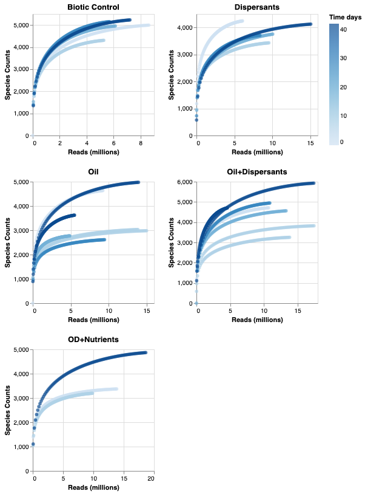

```python
alt.data_transformers.enable('csv')
alt.renderers.enable('jupyterlab')
df_longformat = rarefaction_df_smaller
numcols=2 # specify the number of columns you want
all_categories=df_longformat['Treatment'].unique()

rows=alt.vconcat(data=df_longformat)
numrows=int(np.ceil(len(all_categories) / numcols))
pointer=0

for _ in range(numrows):
    row=all_categories[pointer:pointer+numcols]
    cols=alt.hconcat()
    for a_chart in row:
        line = alt.Chart().mark_circle().encode(
            x='Reads (millions):Q',
            y='Species Counts:Q',
            color='Time days:Q').transform_filter(datum.Treatment == a_chart).properties(title=a_chart, height=200, width=200)
        cols |= line
    rows &= cols
    pointer += numcols
figS4=rows
figS4
```

**Alpha diversity**

We are generating the plot with changes in alpha diversity. Let's remember that the alpha diversity estimate is a single number that summarizes the distribution of species-level annotations in a dataset. The Shannon diversity index is an abundance-weighted average of the logarithm of the relative abundances of annotated species. We compute the species richness as the antilog of the Shannon diversity:

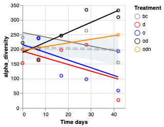

```python
#Subset columns for QC figure

ad_df=sk_df.loc[:,['sample_id','alpha_diversity']]
vec_1 = pd.DataFrame({'Time days':[0,7,17,28,42,0,7,17,28,42,0,7,7,17,28,42,42,0,7,7,17,28,42,42,0,7,42]})
vec_2 = pd.DataFrame({'Treatment' : ['bc', 'bc', 'bc', 'bc', 'bc', 'd', 'd', 'd', 'd', 'd', 'o', 'o', 'o', 'o', 'o', 'o', 'o','od','od','od','od','od','od','od', 'odn', 'odn', 'odn']})
ad_df1 = ad_df.join(vec_1).join(vec_2)

#Linear regression of all data points together

x=ad_df1['Time days']
x=sm.add_constant(x)
y=ad_df1.alpha_diversity
regr = sm.OLS(y, x)
res = regr.fit()

# Get fitted values from model to plot

st, data, ss2 = summary_table(res, alpha=0.05)
fitted_values_df = pd.DataFrame({'fitted_values':data[:,2]})

# Get the confidence intervals of the model

ci_values_df = pd.DataFrame(data[:,4:6])
ad_df2 = x.join(y).join(fitted_values_df).join(ci_values_df)
ad_df2.columns= ['const', 'Time days', 'alpha_diversity', 'fitted_values','ci_down', 'ci_up']
ad_df3 = ad_df2.loc[:,['Time days','ci_down', 'ci_up']]
ad_df3.drop_duplicates(inplace=True)
ad_df3.sort_values(by='Time days', inplace=True)

part_1 = alt.Chart(ad_df1).mark_point().encode(
    x='Time days',
    y='alpha_diversity',
color = alt.Color('Treatment', scale=alt.Scale(domain=['bc', 'd', 'o', 'od', 'odn'], range=['gray', 'red', 'blue', 'black', 'darkorange'])),
).properties(height=200, width=200)

part_2 = alt.Chart(ad_df2).mark_line(strokeDash=[10,4], color='gray', strokeWidth = 5, strokeOpacity = 0.3).encode(
    x='Time days',
    y='fitted_values',
).properties(height=200, width=200)

part_3 = alt.Chart(ad_df3).mark_area(opacity=0.1).encode(
    x='Time days',
    y=alt.Y('ci_down', axis=alt.Axis(title='alpha_diversity')),
    y2='ci_up'
).properties(height=200, width=200)

plot_xx = part_1 + part_2 + part_3

#Creating a loop of linear regressions for each treatment category # Define the degree of the polynomial fit
treatment_list = ['bc', 'd', 'o', 'od', 'odn']
colors = ['gray', 'red', 'blue', 'black', 'darkorange']
i=0
for treat in treatment_list:
    slice_df = ad_df1[(ad_df1['Treatment']==treat)]
    x=slice_df['Time days']
    x=sm.add_constant(x)
    y=slice_df.alpha_diversity
    regr = sm.OLS(y, x)
    res = regr.fit()
    # Get fitted values from model to plot
    st, data, ss2 = summary_table(res, alpha=0.05)
    fitted_values_df = pd.DataFrame({'fitted_values':data[:,2]})
    x = x.reset_index(drop=True)
    melted_df = pd.concat([fitted_values_df,x],axis=1)
    plot_x = alt.Chart(melted_df).mark_line(color=colors[i]).encode(x='Time days', y='fitted_values').properties(height=200, width=200)
    plot_xx = plot_xx + plot_x
    i = i+1

fig8 = plot_xx
fig8
```

**Supplementary Figure 6**

We will define some functions. We will use them frequently in this section.

```python
def get_important_features(transformed_features, components_, columns):
    """
    This function will return the most "important"
    features so we can determine which have the most
    effect on multi-dimensional scaling
    """
    num_columns = len(columns)
    # Scale the principal components by the max value in
    # the transformed set belonging to that component
    xvector = components_[0] * max(transformed_features[:,0])
    yvector = components_[1] * max(transformed_features[:,1])

    # Sort each column by it's length. These are your *original*
    # columns, not the principal components.
    important_features = { columns[i] : math.sqrt(xvector[i]**2 + yvector[i]**2) for i in range(num_columns) }
    important_features = sorted(zip(important_features.values(),important_features.keys()), reverse=True)
    return(important_features)
```

```python
def draw_vectors(transformed_features, components_, columns, max_num_vectors):
    """
    This funtion will project your *original* features
    onto your principal component feature-space, so that you can
    visualize how "important" each one was in the
    multi-dimensional scaling
    """
    num_columns = len(columns)

    # Scale the principal components by the max value in
    # the transformed set belonging to that component
    n0vector = [0] * num_columns
    x1vector = components_[0] * max(transformed_features[:,0])
    y1vector = components_[1] * max(transformed_features[:,1])

    #Calculate euclidean distance
    disvector = np.sqrt(np.square(x1vector - n0vector) + np.square(y1vector - n0vector))
    s1 = pd.Series(columns)
    s2 = pd.Series(x1vector)
    s3 = pd.Series(y1vector)
    s4 = pd.Series(disvector)

    arrows_df = pd.DataFrame([s1, s2, s3, s4])
    arrows_df = arrows_df.transpose()
    arrows_df.columns = ['label','x','y', 'D']
    arrows_df = arrows_df.sort_values(by=['D'], ascending=False)
    arrows_df = arrows_df.head(max_num_vectors)

    n0vector = [0] * max_num_vectors

    s1 = pd.Series(arrows_df['label']).reset_index(drop=True)
    s2 = pd.Series(n0vector)
    s3 = pd.Series(n0vector)
    s4 = pd.Series(arrows_df['D']).reset_index(drop=True)

    arrows_2_df = pd.DataFrame([s1, s2, s3, s4])
    arrows_2_df = arrows_2_df.transpose()
    arrows_2_df.columns = ['label','x','y', 'D']
    frames = [arrows_df, arrows_2_df]
    arrows_3_df = pd.concat(frames)
    return arrows_3_df
```

```python
def pca_subsystems(the_dataframe, max_num_vectors):
    y = the_dataframe.index.values
    x = the_dataframe.values
    xx = StandardScaler().fit_transform(x)
    the_pca = PCA(n_components=2)
    the_pca.fit(the_dataframe)
    the_T = the_pca.transform(the_dataframe)
    the_explainedvector = the_pca.explained_variance_ratio_
    the_components = pd.DataFrame(the_pca.components_, columns = the_dataframe.columns, index=[1, 2])
    the_important_features = get_important_features(the_T, the_pca.components_,the_dataframe.columns.values)
    the_ax = draw_vectors(the_T, the_pca.components_, the_dataframe.columns.values, max_num_vectors)
    the_T_df = pd.DataFrame(the_T)
    the_T_df.columns = ['x', 'y']
    d = {'Treatment': ['BC', 'BC', 'BC', 'BC', 'BC', 'D', 'D', 'D', 'D', 'D', 'ODN', 'ODN', 'ODN', 'OD', 'OD', 'OD', 'OD', 'OD', 'OD', 'OD', 'O', 'O', 'O', 'O', 'O', 'O', 'O'], 'Time': ['10', '17', '27', '38', '52', '10', '17', '27', '38', '52', '10', '17', '52', '10', '17', '17', '27', '38', '52', '52', '10', '17', '17', '27', '38', '52', '52']}
    temp_df = pd.DataFrame(data=d)
    the_T_df = the_T_df.join(temp_df)
    return (the_explainedvector, the_important_features, the_ax, the_T_df)
```

```python
#Loading data

Location = './SK_subsystems_level_1_WITH_REPS.tsv'

#Processing

input_df = pd.read_csv(Location, sep= '\t', error_bad_lines=False)
input_df['samples'] = input_df.index
input_df_1 = input_df.loc[:,['samples', 'dataset', 'abundance']].pivot(index='samples', columns='dataset')['abundance']

my_expl, my_important, my_ax, my_Tdf  = pca_subsystems(input_df_1, 10)
```

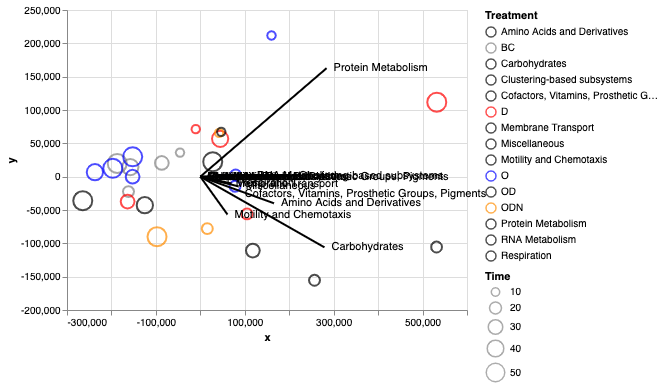

```python
vectorpart1 = alt.Chart(my_ax).mark_line().encode(
    x='x',
    y='y',
    color=alt.Color('label', legend=None))

vectorpart2 = alt.Chart(my_ax).mark_line().encode(
    x='x',
    y='y')

vectortext_1 = vectorpart2.mark_text(
    align='left',
    baseline='middle',
    dx=7
).encode(
    text='label'
)

scale = alt.Scale(domain=['Amino Acids and Derivatives', 'BC', 'Carbohydrates', 'Clustering-based subsystems', 'Cofactors, Vitamins, Prosthetic Groups,Pigments', 'D', 'Membrane Transport', 'Miscellaneous', 'Motility and Chemotaxis', 'O', 'OD', 'ODN', 'Protein Metabolism', 'RNA Metabolism', 'Respiration'],
                   range=['black', 'gray', 'black', 'black', 'black', 'red', 'black', 'black', 'black', 'blue', 'black', 'darkorange', 'black', 'black', 'black'])
dotspart = alt.Chart(my_Tdf).mark_point().encode(
    x='x',
    y='y',
    color=alt.Color('Treatment', legend=alt.Legend(title='Treatment'), scale=scale),
    size='Time:Q'
)

figS6A = dotspart + vectorpart1 + vectortext_1
figS6A
```

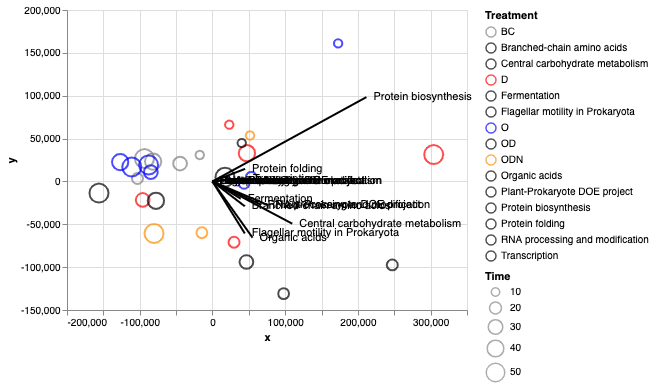

```python
Location = r'./SK_subsystems_level_2_WITH_REPS.tsv'
input_df = pd.read_csv(Location, sep= '\t', error_bad_lines=False).reset_index()
input_df_1 = input_df.loc[:,['level_0', 'dataset', 'abundance']].pivot(index='level_0', columns='dataset')['abundance']
input_df_1 = input_df_1.loc[:, input_df_1.columns.notnull()]
input_df_1 = input_df_1.fillna(0)

my_expl, my_important, my_ax, my_Tdf = pca_subsystems(input_df_1, 10)

vectorpart1 = alt.Chart(my_ax).mark_line().encode(
    x='x',
    y='y',
    color=alt.Color('label', legend=None) )

vectorpart2 = alt.Chart(my_ax).mark_line().encode(
    x='x',
    y='y' )

vectortext_1 = vectorpart2.mark_text(
    align='left',
    baseline='middle',
    dx=7
).encode(
    text='label'
)

scale = alt.Scale(domain=['BC', 'Branched-chain amino acids', 'Central carbohydrate metabolism', 'D', 'Fermentation', 'Flagellar motility in Prokaryota', 'O', 'OD', 'ODN','Organic acids', 'Plant-Prokaryote DOE project', 'Protein biosynthesis', 'Protein folding', 'RNA processing and modification', 'Transcription'],
                   range=['gray', 'black', 'black', 'red', 'black', 'black', 'blue', 'black', 'darkorange', 'black', 'black', 'black', 'black', 'black', 'black'])

dotspart = alt.Chart(my_Tdf).mark_point().encode(
    x='x',
    y='y',
    color=alt.Color('Treatment', legend=alt.Legend(title='Treatment'), scale=scale),
    size='Time:Q'
)

figS6B = dotspart + vectorpart1 + vectortext_1
figS6B
```

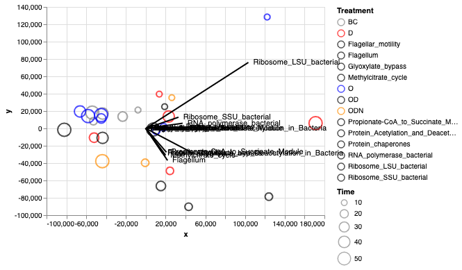

```python
 #Inspection of detailed table
Location = r'./SK_subsystems_level_3_WITH_REPS.tsv'

#Processing

input_df = pd.read_csv(Location, sep= '\t', error_bad_lines=False, encoding = "ISO-8859-1").reset_index()
input_df_1 = input_df.loc[:, ['level3', 'BC_0', 'BC_1', 'BC_2', 'BC_3', 'BC_4','D_0', 'D_1', 'D_2', 'D_3', 'D_4', 'ODN_0', 'ODN_1', 'ODN_4', 'OD_0', 'OD_1_1', 'OD_1_2', 'OD_2', 'OD_3', 'OD_4_1', 'OD_4_2', 'O_0', 'O_1_1', 'O_1_2', 'O_2', 'O_3', 'O_4_1', 'O_4_2']]
input_df_1 = input_df_1.set_index(['level3'])
input_df_1 = input_df_1.T
my_expl, my_important, my_ax, my_Tdf  = pca_subsystems(input_df_1, 10)

vectorpart1 = alt.Chart(my_ax).mark_line().encode(
    x='x',
    y='y',
    color=alt.Color('label', legend=None) )

vectorpart2 = alt.Chart(my_ax).mark_line().encode(
    x='x',
    y='y' )

vectortext_1 = vectorpart2.mark_text(
    align='left',
    baseline='middle',
    dx=7
).encode(
    text='label'
)

scale = alt.Scale(domain=['BC', 'D', 'Flagellar_motility', 'Flagellum', 'Glyoxylate_bypass', 'Methylcitrate_cycle',
                          'O', 'OD', 'ODN',
                          'Propionate-CoA_to_Succinate_Module','Protein_Acetylation_and_Deacetylation_in_Bacteria', 'Protein_chaperones',
                          'RNA_polymerase_bacterial', 'Ribosome_LSU_bacterial', 'Ribosome_SSU_bacterial'],
                    range=['gray', 'red', 'black', 'black', 'black', 'black',
                         'blue', 'black', 'darkorange',
                         'black', 'black', 'black',
                         'black', 'black', 'black'])

dotspart = alt.Chart(my_Tdf).mark_point().encode(
    x='x',
    y='y',
    color=alt.Color('Treatment', legend=alt.Legend(title='Treatment'), scale=scale),
    size='Time:Q'
)

figS6C = dotspart + vectorpart1 + vectortext_1
figS6C
```

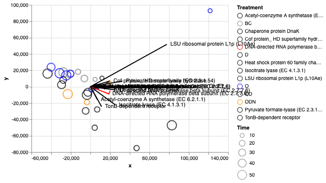

```python
Location = r'./SK_subsystems_level_4_WITH_REPS.tsv'
input_df = pd.read_csv(Location, sep= '\t', error_bad_lines=False, encoding ="ISO-8859-1").reset_index()
input_df_1 = input_df.loc[:, ['function', 'BC_0', 'BC_1', 'BC_2', 'BC_3', 'BC_4', 'D_0', 'D_1', 'D_2', 'D_3', 'D_4', 'ODN_0', 'ODN_1', 'ODN_4', 'OD_0', 'OD_1_1', 'OD_1_2', 'OD_2', 'OD_3', 'OD_4_1', 'OD_4_2', 'O_0', 'O_1_1', 'O_1_2', 'O_2', 'O_3', 'O_4_1', 'O_4_2']]
input_df_1 = input_df_1.set_index(['function'])
input_df_1 = input_df_1.T

my_expl, my_important, my_ax, my_Tdf  = pca_subsystems(input_df_1, 10)

vectorpart1 = alt.Chart(my_ax).mark_line().encode(
    x='x',
    y='y',
    color=alt.Color('label', legend=None) )

vectorpart2 = alt.Chart(my_ax).mark_line().encode(
    x='x',
    y='y' )

vectortext_1 = vectorpart2.mark_text(
    align='left',
    baseline='middle',
    dx=7
).encode(
    text='label'
)

scale = alt.Scale(domain=['Acetyl-coenzyme A synthetase (EC 6.2.1.1)',
                            'BC', 'Chaperone protein DnaK', 'Cof protein_ HD superfamily hydrolase', 'DNA-directed RNA polymerase beta subunit (EC 2.7.7.6)',
                            'D', 'Heat shock protein 60 family chaperone GroEL','Isocitrate lyase (EC 4.1.3.1)', 'LSU ribosomal protein L1p (L10Ae)',
                            'O',
                            'OD',
                            'ODN',
                            'Pyruvate formate-lyase (EC 2.3.1.54)', 'TonB-dependent receptor'],
range=['black',
        'gray', 'black', 'black',
       'red',  'black', 'black', 'black', 'black',
       'blue', 'black', 'darkorange',
        'black',  'black'])

dotspart = alt.Chart(my_Tdf).mark_point().encode(
    x='x',
    y='y',
    color=alt.Color('Treatment', legend=alt.Legend(title='Treatment'), scale=scale),
    size='Time:Q'
)

figS6D = dotspart + vectorpart1 + vectortext_1
figS6D
```

```python
#Inspection of detailed table
Location = r'./SK_subsystems_level_2_WITH_REPS.tsv'
input_df = pd.read_csv(Location, sep= '\t', error_bad_lines=False).reset_index()
input_df = input_df.loc[(input_df['level_1'] == 'Motility and Chemotaxis') | (input_df['level_1'] == 'Carbohydrates') | (input_df['level_1'] == 'Membrane Transport') | (input_df['level_1'] == 'Respiration') ]
input_df_1 = input_df.loc[:,['level_0', 'dataset', 'abundance']].pivot(index='level_0', columns='dataset')['abundance']
input_df_1 = input_df_1.loc[:, input_df_1.columns.notnull()]
```

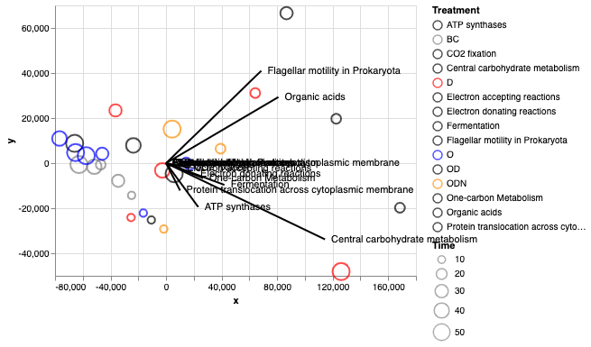

```python
my_expl, my_important, my_ax, my_Tdf  = pca_subsystems(input_df_1, 10)

vectorpart1 = alt.Chart(my_ax).mark_line().encode(
    x='x',
    y='y',
    color=alt.Color('label', legend=None) )

vectorpart2 = alt.Chart(my_ax).mark_line().encode(
    x='x',
    y='y' )

vectortext_1 = vectorpart2.mark_text(
    align='left',
    baseline='middle',
    dx=7
).encode(
    text='label'
)

scale = alt.Scale(domain=['ATP synthases',
                         'BC', 'CO2 fixation', 'Central carbohydrate metabolism',
                         'D', 'Electron accepting reactions', 'Electron donating reactions', 'Fermentation', 'Flagellar motility in Prokaryota',
                         'O',
                         'OD',
                         'ODN', 'One-carbon Metabolism', 'Organic acids', 'Protein translocation across cytoplasmic membrane'],
                  range=['black',
                         'gray', 'black', 'black',
                         'red', 'black', 'black',  'black', 'black',
                         'blue', 'black', 'darkorange', 'black', 'black', 'black'])
dotspart = alt.Chart(my_Tdf).mark_point().encode(
    x='x',
    y='y',
    color=alt.Color('Treatment', legend=alt.Legend(title='Treatment'),scale=scale),
    size='Time:Q'
)

figS6E = dotspart + vectorpart1 + vectortext_1
figS6E
```

```python
 #Inspection of detailed table
Location = r'./SK_subsystems_level_3_WITH_REPS.tsv'
input_df = pd.read_csv(Location, sep= '\t', error_bad_lines=False, encoding ="ISO-8859-1").reset_index()
input_df = input_df.loc[(input_df['level1'] == 'Motility and Chemotaxis') | (input_df['level1'] == 'Carbohydrates') | (input_df['level1'] == 'Membrane Transport') | (input_df['level1'] == 'Respiration') ]

input_df_1 = input_df.loc[:, ['level3', 'BC_0', 'BC_1', 'BC_2', 'BC_3', 'BC_4','D_0', 'D_1', 'D_2', 'D_3', 'D_4', 'ODN_0', 'ODN_1', 'ODN_4', 'OD_0','OD_1_1', 'OD_1_2', 'OD_2', 'OD_3', 'OD_4_1', 'OD_4_2', 'O_0', 'O_1_1','O_1_2', 'O_2', 'O_3', 'O_4_1', 'O_4_2']]
input_df_1 = input_df_1.set_index(['level3'])
input_df_1 = input_df_1.T
```

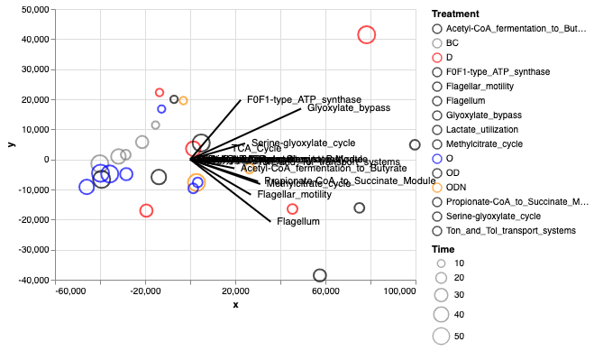

```python
my_expl, my_important, my_ax, my_Tdf  = pca_subsystems(input_df_1, 10)

vectorpart1 = alt.Chart(my_ax).mark_line().encode(
    x='x',
    y='y',
    color=alt.Color('label', legend=None) )

vectorpart2 = alt.Chart(my_ax).mark_line().encode(
    x='x',
    y='y' )

vectortext_1 = vectorpart2.mark_text(
    align='left',
    baseline='middle',
    dx=7
).encode(
    text='label'
)


scale = alt.Scale(domain=['Acetyl-CoA_fermentation_to_Butyrate',
                         'BC',
                         'D',
                         'F0F1-type_ATP_synthase',
                         'Flagellar_motility',
                         'Flagellum',
                         'Glyoxylate_bypass',
                         'Lactate_utilization',
                         'Methylcitrate_cycle',
                         'O',
                         'OD',
                         'ODN',
                         'Propionate-CoA_to_Succinate_Module',
                         'Serine-glyoxylate_cycle',
                         'Ton_and_Tol_transport_systems'],
                  range=['black',
                        'gray',
                        'red',
                        'black',
                        'black',
                         'black',
                         'black',
                         'black',
                         'black',
                         'blue',
                         'black',
                         'darkorange',
                         'black',
                         'black',
                         'black'])

dotspart = alt.Chart(my_Tdf).mark_point().encode(
    x='x',
    y='y',
color=alt.Color('Treatment', legend=alt.Legend(title='Treatment'),scale=scale),
    size='Time:Q'
)

figS6F = dotspart + vectorpart1 + vectortext_1
figS6F
```

**Figure 3B**

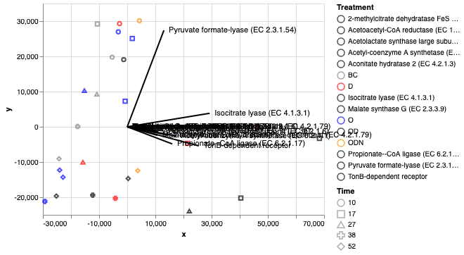

```python
 #Inspection of detailed table
Location = r'./SK_subsystems_level_4_WITH_REPS.tsv'
input_df = pd.read_csv(Location, sep= '\t', error_bad_lines=False, encoding ="ISO-8859-1").reset_index()
input_df = input_df.loc[(input_df['level1'] == 'Motility and Chemotaxis') |(input_df['level1'] == 'Carbohydrates') | (input_df['level1'] == 'Membrane Transport') | (input_df['level1'] == 'Respiration') ]

input_df_1 = input_df.loc[:, ['function', 'BC_0', 'BC_1', 'BC_2', 'BC_3', 'BC_4', 'D_0', 'D_1', 'D_2', 'D_3', 'D_4', 'ODN_0', 'ODN_1', 'ODN_4', 'OD_0', 'OD_1_1', 'OD_1_2', 'OD_2', 'OD_3', 'OD_4_1', 'OD_4_2', 'O_0', 'O_1_1', 'O_1_2', 'O_2', 'O_3', 'O_4_1', 'O_4_2']]
input_df_1 = input_df_1.set_index(['function'])
input_df_1 = input_df_1.T

my_expl, my_important, my_ax, my_Tdf = pca_subsystems(input_df_1, 10)

vectorpart1 = alt.Chart(my_ax).mark_line().encode(
    x='x',
    y='y',
    color=alt.Color('label', legend=None) )

vectorpart2 = alt.Chart(my_ax).mark_line().encode(
    x='x',
    y='y' )

vectortext_1 = vectorpart2.mark_text(
    align='left',
    baseline='middle',
    dx=7
).encode(
    text='label'
)

scale = alt.Scale(domain=['2-methylcitrate dehydratase FeS dependent (EC 4.2.1.79)',
                            'Acetoacetyl-CoA reductase (EC 1.1.1.36)',
                            'Acetolactate synthase large subunit (EC 2.2.1.6)',
                            'Acetyl-coenzyme A synthetase (EC 6.2.1.1)',
                            'Aconitate hydratase 2 (EC 4.2.1.3)',
                            'BC',
                            'D',
                            'Isocitrate lyase (EC 4.1.3.1)',
                            'Malate synthase G (EC 2.3.3.9)',
                            'O',
                             'OD',
                             'ODN',
                             'Propionate--CoA ligase (EC 6.2.1.17)',
                             'Pyruvate formate-lyase (EC 2.3.1.54)',
                             'TonB-dependent receptor'],
                    range=['black',
                             'black',
                             'black',
                             'black',
                             'black',
                             'gray',
                             'red',
                             'black',
                             'black',
                             'blue',
                             'black',
                             'darkorange',
                             'black',
                             'black',
                             'black',
                             'black'])

dotspart = alt.Chart(my_Tdf).mark_point().encode(
    x='x',
    y='y',
    color=alt.Color('Treatment', legend=alt.Legend(title='Treatment'),scale=scale),
    shape='Time:N'
)

fig3B = dotspart + vectorpart1 + vectortext_1
fig3B
```

**Figure 3A**

This section was run in R (`PeñaMontenegro_et_al_2020_R_b-diversity.ipynb`). Here we are going to plot one of the outputs.

```python
Location = r'./Fig3_pca_samples.csv'
betasamples_df = pd.read_csv(Location, sep= ',', error_bad_lines=False, encoding = "ISO-8859-1").reset_index()
betasamples_df.columns = ['col1', 'Tag', 'PC1', 'PC2']
betasamples_df = betasamples_df.drop(['col1'], axis=1)
```

```python
betasamples_df['Treatment'] = ['Bacterial Control', 'Bacterial Control','Bacterial Control','Bacterial Control','Bacterial Control','Dispersants', 'Dispersants', 'Dispersants', 'Dispersants', 'Dispersants','WAF','WAF','WAF','WAF','WAF','WAF','WAF','CEWAF','CEWAF','CEWAF','CEWAF','CEWAF','CEWAF','CEWAF','CEWAF + nutrients', 'CEWAF + nutrients', 'CEWAF + nutrients']
betasamples_df['Time'] = [0, 7, 17, 28, 42, 0, 7, 17, 28, 42, 0, 7, 7, 17, 28, 42, 42, 0, 7, 7, 17, 28, 42, 42, 0, 7, 42]
```

```python
#Let's upload the relative counts for taxonomy
Location = r'./Fig3_pca_species.csv'
betaspecies_df = pd.read_csv(Location, sep= ',', error_bad_lines=False, encoding = "ISO-8859-1").reset_index()
betaspecies_df.columns = ['col1', 'Tag', 'PC1', 'PC2']
betaspecies_df = betaspecies_df.drop(['col1'], axis=1)
```

```python
betaspecies_df.PC2 = betaspecies_df.PC2 * 5
```

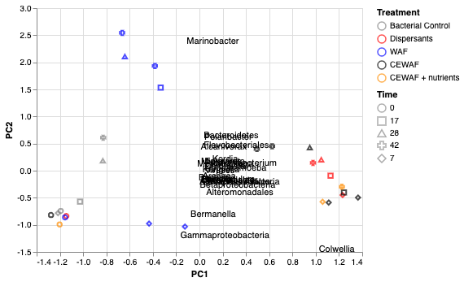

```python
p1 = alt.Chart(betasamples_df).mark_point().encode(
    x='PC1',
    y='PC2',
    color=alt.Color('Treatment', legend=alt.Legend(title='Treatment'), scale=alt.Scale(domain=['Bacterial Control', 'Dispersants', 'WAF', 'CEWAF','CEWAF + nutrients'], range=['gray', 'red', 'blue', 'black', 'darkorange'])),
    shape='Time:N',
)
p2 = alt.Chart(betaspecies_df).mark_text(
    align='left',
    baseline='middle',
    dx=7
).encode(
    x='PC1',
    y='PC2',
    text='Tag'
)
fig3A = p1 + p2
fig3A
```

**Figure 2**

```python
Location = r'./16S_VAMPS.tsv'
input_df = pd.read_csv(Location, sep= '\t', error_bad_lines=False).reset_index()
single_terms = []
for i in input_df.iloc[:,1]:
    terms = i.split(";")
    single_terms.append(terms[-1])

se = pd.Series(single_terms)
input_df['tag'] = se.values
input_df1 = input_df[['tag',
          'BC_0_1', 'BC_0_2', 'BC_0_3',
          'BC_1_1', 'BC_1_2', 'BC_1_3',
          'BC_2_1', 'BC_2_2', 'BC_2_3',
          'BC_3_1', 'BC_3_2', 'BC_3_3',
          'BC_4_1', 'BC_4_2', 'BC_4_3',
          'D_0_1', 'D_0_2', 'D_0_3',
          'D_1_1', 'D_1_2', 'D_1_3',
          'D_2_1', 'D_2_2', 'D_2_3',
          'D_3_1', 'D_3_2', 'D_3_3',
          'D_4_1', 'D_4_2', 'D_4_3',
          'O_0_1', 'O_0_2', 'O_0_3',
          'O_1_1', 'O_1_2', 'O_1_3',
          'O_2_1', 'O_2_2', 'O_2_3',
          'O_3_1', 'O_3_2', 'O_3_3',
          'O_4_1', 'O_4_2', 'O_4_3',
          'OD_0_1', 'OD_0_2', 'OD_0_3',
          'OD_1_1', 'OD_1_2', 'OD_1_3',
          'OD_2_1', 'OD_2_2', 'OD_2_3',
          'OD_3_1', 'OD_3_2', 'OD_3_3',
          'OD_4_1', 'OD_4_2', 'OD_4_3',
          'ODN_0_1', 'ODN_0_2', 'ODN_0_3',
          'ODN_1_1', 'ODN_1_2', 'ODN_1_3',
          'ODN_4_1', 'ODN_4_2', 'ODN_4_3'
         ]]
input_df1 = input_df1.set_index('tag')
input_df1 = input_df1.T
treatag = np.arange(1,70)
se = pd.Series(treatag)
input_df1['TreatTag'] = se.values
input_df1 = pd.melt(input_df1, id_vars=['TreatTag'], var_name='Taxonomy', value_name='Counts')
input_df1 = input_df1[["Taxonomy", "TreatTag", "Counts"]]
input_df1.to_csv(path_or_buf="16S_format4r.txt", sep="\t", header=False, index=False)
```

```python
#Download and run Perl script
!rm mgrastrawcounts_to_goldDBtagscounts.pl
!rm SK_metaT_v2.db.zip
!rm SK_metaT_v2.db
!wget https://github.com/biotemon/GZ_et_al/raw/master/scripts/mgrastrawcounts_to_goldDBtagscounts.pl
!wget https://osf.io/s7u4t/download -O SK_metaT_v2.db.zip
!unzip SK_metaT_v2.db.zip
!cat mgrastrawcounts_to_goldDBtagscounts.pl | sed -e 's/SETDABASEHERE/\.\/SK\_metaT\_v2\.db/' > mgrastrawcounts_to_goldDBtagscounts_v2.pl
!rm mgrastrawcounts_to_goldDBtagscounts.pl
!mv mgrastrawcounts_to_goldDBtagscounts_v2.pl mgrastrawcounts_to_goldDBtagscounts.pl
#Run the code
!perl mgrastrawcounts_to_goldDBtagscounts.pl 16S_format4r.txt
```

```
--2020-09-05 21:45:29--  https://github.com/biotemon/GZ_et_al/raw/master/scripts/mgrastrawcounts_to_goldDBtagscounts.pl
Resolving github.com (github.com)... 140.82.114.4
Connecting to github.com (github.com)|140.82.114.4|:443... connected.
HTTP request sent, awaiting response... 302 Found
Location: https://raw.githubusercontent.com/biotemon/GZ_et_al/master/scripts/mgrastrawcounts_to_goldDBtagscounts.pl [following]
--2020-09-05 21:45:29--  https://raw.githubusercontent.com/biotemon/GZ_et_al/master/scripts/mgrastrawcounts_to_goldDBtagscounts.pl
Resolving raw.githubusercontent.com (raw.githubusercontent.com)... 199.232.32.133
Connecting to raw.githubusercontent.com (raw.githubusercontent.com)|199.232.32.133|:443... connected.
HTTP request sent, awaiting response... 200 OK
Length: 17972 (18K) [text/plain]
Saving to: ‘mgrastrawcounts_to_goldDBtagscounts.pl’

mgrastrawcounts_to_ 100%[===================>]  17.55K  --.-KB/s    in 0.01s

2020-09-05 21:45:30 (1.46 MB/s) - ‘mgrastrawcounts_to_goldDBtagscounts.pl’ saved [17972/17972]

--2020-09-05 21:45:30--  https://osf.io/s7u4t/download
Resolving osf.io (osf.io)... 35.190.84.173
Connecting to osf.io (osf.io)|35.190.84.173|:443... connected.
HTTP request sent, awaiting response... 302 FOUND
Location: https://files.osf.io/v1/resources/fu9bw/providers/dropbox/SK_metaT_v_may_28_2019.db.zip?action=download&direct&version [following]
--2020-09-05 21:45:31--  https://files.osf.io/v1/resources/fu9bw/providers/dropbox/SK_metaT_v_may_28_2019.db.zip?action=download&direct&version
Resolving files.osf.io (files.osf.io)... 35.186.214.196
Connecting to files.osf.io (files.osf.io)|35.186.214.196|:443... connected.
HTTP request sent, awaiting response... 200 OK
Length: 90160523 (86M) [application/octet-stream]
Saving to: ‘SK_metaT_v2.db.zip’

SK_metaT_v2.db.zip  100%[===================>]  85.98M  9.22MB/s    in 9.7s

2020-09-05 21:45:42 (8.87 MB/s) - ‘SK_metaT_v2.db.zip’ saved [90160523/90160523]

Archive:  SK_metaT_v2.db.zip
  inflating: SK_metaT_v2.db
Determining taxonomic query terms
 99% [========================================================================*]Updating taxonomy database and getting tax_ids
 19% [==============                                                           ]Use of uninitialized value in concatenation (.) or string at mgrastrawcounts_to_goldDBtagscounts.pl line 122.
Use of uninitialized value $rkingdom in string ne at mgrastrawcounts_to_goldDBtagscounts.pl line 175.
Use of uninitialized value $rkingdom in string ne at mgrastrawcounts_to_goldDBtagscounts.pl line 250.
Use of uninitialized value $rsuperkingdom in string ne at mgrastrawcounts_to_goldDBtagscounts.pl line 250.
100% [=========================================================================]Processing taxonomyXcounts table
 99% [========================================================================*]Processing add_manually_terms file
```

```python
#Download R script
!rm plot_CommunityStructure.R
!wget https://raw.githubusercontent.com/biotemon/K2015/master/scripts/plot_CommunityStructure_vSK_v2.R
!mv plot_CommunityStructure_vSK_v2.R plot_CommunityStructure.R
```

```
--2020-09-05 21:58:04--  https://raw.githubusercontent.com/biotemon/K2015/master/scripts/plot_CommunityStructure_vSK_v2.R
Resolving raw.githubusercontent.com (raw.githubusercontent.com)... 199.232.32.133
Connecting to raw.githubusercontent.com (raw.githubusercontent.com)|199.232.32.133|:443... connected.
HTTP request sent, awaiting response... 200 OK
Length: 17206 (17K) [text/plain]
Saving to: ‘plot_CommunityStructure_vSK_v2.R’

plot_CommunityStruc 100%[===================>]  16.80K  --.-KB/s    in 0.01s

2020-09-05 21:58:04 (1.10 MB/s) - ‘plot_CommunityStructure_vSK_v2.R’ saved [17206/17206]
```

```python
#Definition of some important variables
cwd = os.getcwd()

viz_threshold = '4'

#Concatenating names of samples
samples_string = '", "'.join(str(v) for v in treatag)

# Read in the file
with open('plot_CommunityStructure.R', 'r') as file :
  filedata = file.read()
#Setting Desired Order
filedata = filedata.replace('SETDESIREDBARORDERHERE', samples_string)

#Setting sample names of libraries matching the desired order
filedata = filedata.replace('SETSAMPLENUMBERSHERE', samples_string)

# Setting visualization threshold
filedata = filedata.replace('SETTHRESHOLDHERE', viz_threshold)

# Setting working directory
filedata = filedata.replace('SETWORKINGDIRHERE', cwd)

# Setting taxcounts file
filedata = filedata.replace('SETTAXCOUNTSFILEHERE', '16S_format4r.txt_taxonomyXcounts.txt' )

# Setting sample names
filedata = filedata.replace('SETSAMPLENAMESHERE', samples_string)

colortochange = "\n".join([ 'simple_color_vec[2] <- "#512888" #KSU purple',
'simple_color_vec[3] <- "#D8BFD8" #Thistle',
'simple_color_vec[4] <- "#cc12c0" #Fucsia',
'simple_color_vec[5] <- "#9E0142" #Red',
'simple_color_vec[6] <- "#ff9e9e" #Light red',
'simple_color_vec[7] <- "#DC143C" #Crimson',
'simple_color_vec[8] <- "#ff6f00" #Orange',
'simple_color_vec[9] <- "#FFEF00" #Process Yellow',
'simple_color_vec[10] <- "#FFD700" #Golden yellow',
'simple_color_vec[11] <- "#D2691E" #Cocoa brown',
'simple_color_vec[12] <-"#008000" #Green HTML',
'simple_color_vec[13] <-"#8db500" #Verde mango biche',
'simple_color_vec[14] <- "#ACE1AF" #Celadon',
'simple_color_vec[15] <- "#e6ffe6" #Colwellia',
'simple_color_vec[16] <- "#4B6F44" #Artichoke Pantone',
'simple_color_vec[17] <-"#72996c" #Verde gris',
'simple_color_vec[18] <-"#A8E224" #Green 7',
'simple_color_vec[19] <- "#008080" #Teal',
'simple_color_vec[20] <-"#a3cece" #Teal clarito',
'simple_color_vec[21] <- "#118200" #Verde pasto',
'simple_color_vec[22] <-"#CAD32E" #Green 11',
'simple_color_vec[23] <-"#DFFF00" #Chartreuse',
'simple_color_vec[24] <- "#DADD98" #Green earth'
'simple_color_vec[25] <- "#00b2ff" #blue',
'simple_color_vec[26] <- "#97c6bf" #Light grey blue',
'simple_color_vec[27] <- "#000000" #black',
'simple_color_vec[28] <- "#c7c5c4" #Grey',
 ])

filedata = filedata.replace('#SETCOLORSHERE', colortochange)

# Write the file out again
with open('plot_CommunityStructure.R', 'w') as file:
  file.write(filedata)
```

```python
#Run the R script
!Rscript plot_CommunityStructure.R
```

Now that 16S Data have been summarized at a 4% thereshold of relative abundance, we are going to upload the matrix to generate the 16S vs Metagenome plot

```python
!mv simple_relative_melt.csv 16S_simple_relative_melt.csv
!mv simple_absolute_melt.csv 16S_simple_absolute_melt.csv
```

```python
Location = r'./16S_simple_relative_melt.csv'
input_df = pd.read_csv(Location, sep= ',', error_bad_lines=False).reset_index()
input_df = input_df.drop(['index', 'Unnamed: 0'], axis=1)
rrna_16S_df = input_df[input_df.variable != 'Unknown']
Location = r'./fig1_simple_relative_melt.csv'
metagen_df = pd.read_csv(Location, sep= ',', error_bad_lines=False).reset_index()
```

```python
metagen_df['sample_names'] = metagen_df['sample_names'].replace(['bc0', 'bc1', 'bc2', 'bc3', 'bc4', 'd0', 'd1', 'd2', 'd3', 'd4',
       'o0', 'o1A', 'o1B','o2', 'o3', 'o4A', 'o4B', 'od0', 'od1A','od1B', 'od2', 'od3',
       'od4A', 'od4B', 'odn0', 'odn1', 'odn4'],['bc0', 'bc1', 'bc2', 'bc3', 'bc4', 'd0', 'd1', 'd2', 'd3', 'd4',
       'o0', 'o1', 'o1','o2', 'o3', 'o4', 'o4', 'od0', 'od1','od1', 'od2', 'od3',
       'od4', 'od4', 'odn0', 'odn1', 'odn4'])
```

```python
vec1 = ['o1', 'o4', 'od1', 'od4']
vec2 = metagen_df.variable.unique()
```

```python
for i in vec1:
    for j in vec2:
        temp = metagen_df[(metagen_df3.variable == j) & (metagen_df.sample_names == i)]
        the_mean = temp.value.mean()
        metagen_df.at[temp.index[0],'value'] = the_mean
        metagen_df = metagen_df[metagen_df.index != temp.index[1]]
```

```python
tax_se = metagen_df['variable']
tax_se = tax_se.append(rrna_16S_df['variable'])
uniq_tax = tax_se.unique()
#rrna_16S_df
tags = ['bc0', 'bc0', 'bc0',
        'bc1', 'bc1', 'bc1',
        'bc2', 'bc2', 'bc2',
        'bc3', 'bc3', 'bc3',
        'bc4', 'bc4', 'bc4',
        'd0', 'd0', 'd0',
        'd1', 'd1', 'd1',
        'd2', 'd2', 'd2',
        'd3', 'd3', 'd3',
        'd4', 'd4', 'd4',
        'o0', 'o0', 'o0',
        'o1', 'o1', 'o1',
        'o2', 'o2', 'o2',
        'o3', 'o3', 'o3',
        'o4', 'o4', 'o4',
        'od0', 'od0', 'od0',
        'od1', 'od1', 'od1',
        'od2', 'od2', 'od2',
        'od3', 'od3', 'od3',
        'od4', 'od4', 'od4',
        'odn0', 'odn0', 'odn0',
        'odn1', 'odn1', 'odn1',
        'odn4', 'odn4', 'odn4']
tags1 = tags * 30
tags1 = pd.Series(tags1)
rrna_16S_df['tags'] = tags1.values
```

```python
tag_col = []
tax_col = []
met_col = []
rna_col = []
i = 0
for t in uniq_tax:
    for u in tags:
        if i > 2:
            i = 0
        tag_col.append(u)
        tax_col.append(t)
        x = metagen_df[(metagen_df.variable == t) & (metagen_df.sample_names == u)]['value']
        if x.empty:
            x = '0'
        else:
            x = x.to_string(header=None, index=None)
        met_col.append(x)
        temp = pd.Series(rrna_16S_df[(rrna_16S_df.variable == t) & (rrna_16S_df.tags == u)]['value'])
        temp = temp.reset_index(drop=True)
        if temp.empty:
            y = 0
        else:
            y = temp[i]
        rna_col.append(y)
        i = i + 1
```

```python
d = {'Tag' : pd.Series(tag_col),
       'Taxonomy' : pd.Series(tax_col),
     '16S_Abundance' : pd.Series(rna_col),
     'MG_Abundance' : pd.Series(met_col),
    }
MG_vs_16s_df = pd.DataFrame(d)
```

```python
mg = MG_vs_16s_df['MG_Abundance'].astype(np.float)
rr = MG_vs_16s_df['16S_Abundance'].astype(np.float)
mg = mg + 0.000001
rr = rr + 0.000001
mg_rr_lr = np.log2(mg / rr)
se = pd.Series(mg_rr_lr)
MG_vs_16s_df['MG_16S_Abundance_Ratio']=se.values
```

```python
tags2 = ['Control', 'Control', 'Control',
        'Control', 'Control', 'Control',
        'Control', 'Control', 'Control',
        'Control', 'Control', 'Control',
        'Control', 'Control', 'Control',
        'Dispersant', 'Dispersant', 'Dispersant',
        'Dispersant', 'Dispersant', 'Dispersant',
        'Dispersant', 'Dispersant', 'Dispersant',
        'Dispersant', 'Dispersant', 'Dispersant',
        'Dispersant', 'Dispersant', 'Dispersant',
        'WAF', 'WAF', 'WAF',
        'WAF', 'WAF', 'WAF',
        'WAF', 'WAF', 'WAF',
        'WAF', 'WAF', 'WAF',
        'WAF', 'WAF', 'WAF',
        'CEWAF', 'CEWAF', 'CEWAF',
        'CEWAF', 'CEWAF', 'CEWAF',
        'CEWAF', 'CEWAF', 'CEWAF',
        'CEWAF', 'CEWAF', 'CEWAF',
        'CEWAF', 'CEWAF', 'CEWAF',
        'CEWAF+N', 'CEWAF+N', 'CEWAF+N',
        'CEWAF+N', 'CEWAF+N', 'CEWAF+N',
        'CEWAF+N', 'CEWAF+N', 'CEWAF+N' ]
tags2 = tags2 * 47
```

```python
#insert the new column
MG_vs_16s_df.insert(1, "Treatment", tags2, True)
```

```python
#For the control
control_subset_df = MG_vs_16s_df[MG_vs_16s_df['Treatment'] == 'Control']
means = control_subset_df.groupby('Taxonomy', as_index=False)['MG_16S_Abundance_Ratio'].mean()
means.columns = ['Taxonomy', 'Mean_LR']
control_subset_df = control_subset_df.join(means.set_index('Taxonomy'), on='Taxonomy')
#For oil
oil_subset_df = MG_vs_16s_df[MG_vs_16s_df['Treatment'] == 'WAF']
means = oil_subset_df.groupby('Taxonomy', as_index=False)['MG_16S_Abundance_Ratio'].mean()
means.columns = ['Taxonomy', 'Mean_LR']
oil_subset_df = oil_subset_df.join(means.set_index('Taxonomy'), on='Taxonomy')
#For disp
disp_subset_df = MG_vs_16s_df[MG_vs_16s_df['Treatment'] == 'Dispersant']
means = disp_subset_df.groupby('Taxonomy', as_index=False)['MG_16S_Abundance_Ratio'].mean()
means.columns = ['Taxonomy', 'Mean_LR']
disp_subset_df = disp_subset_df.join(means.set_index('Taxonomy'), on='Taxonomy')
#For oil disp
cewaf_subset_df = MG_vs_16s_df[MG_vs_16s_df['Treatment'] == 'CEWAF']
means = cewaf_subset_df.groupby('Taxonomy', as_index=False)['MG_16S_Abundance_Ratio'].mean()
means.columns = ['Taxonomy', 'Mean_LR']
cewaf_subset_df = cewaf_subset_df.join(means.set_index('Taxonomy'), on='Taxonomy')
#For oil disp nutr
cewafn_subset_df = MG_vs_16s_df[MG_vs_16s_df['Treatment'] == 'CEWAF+N']
means = cewaf_subset_df.groupby('Taxonomy', as_index=False)['MG_16S_Abundance_Ratio'].mean()
means.columns = ['Taxonomy', 'Mean_LR']
cewafn_subset_df = cewafn_subset_df.join(means.set_index('Taxonomy'), on='Taxonomy')
```

```python
frames = [control_subset_df, oil_subset_df, disp_subset_df, cewaf_subset_df, cewafn_subset_df]
all_ratios_df = pd.concat(frames)
```

```python
all_ratios_df = all_ratios_df[all_ratios_df.Taxonomy != "Microvirus"]
all_ratios_df = all_ratios_df[all_ratios_df.Taxonomy != "Viruses"]
all_ratios_df = all_ratios_df[all_ratios_df.Taxonomy != "Eukaryota"]
all_ratios_df = all_ratios_df[all_ratios_df.Taxonomy != "Neoparamoeba"]
all_ratios_df = all_ratios_df[all_ratios_df.Taxonomy != "Archaea"]
```

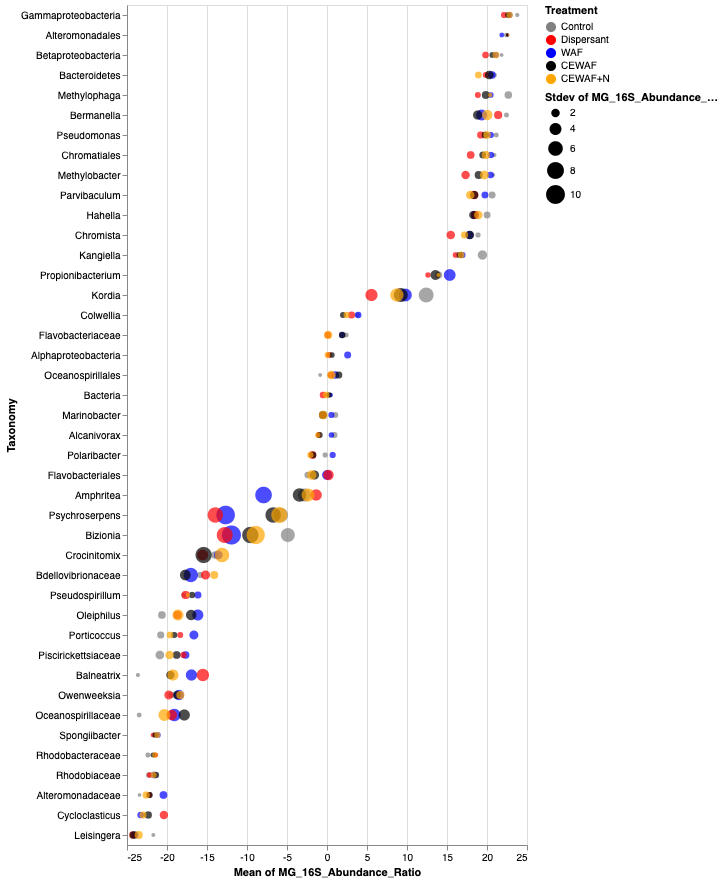

```python
fig2 = alt.Chart(all_ratios_df).mark_point(filled=True).encode(
    alt.X('mean(MG_16S_Abundance_Ratio)', scale=alt.Scale(zero=False)),
    alt.Y(
        'Taxonomy',
        sort=alt.EncodingSortField(field='Mean_LR', op='mean', order='descending'),
        #scale=alt.Scale(rangeStep=20)
    ),
    alt.Color('Treatment', scale=alt.Scale(domain=['Control', 'Dispersant', 'WAF', 'CEWAF', 'CEWAF+N'], range=['gray', 'red', 'blue', 'black', 'orange'])),
    alt.Size('stdev(MG_16S_Abundance_Ratio)')
).configure_mark(opacity=0.7)
fig2
```

**Supplementary Figure 7**

```python
def unique_list(l):
  x = []
  for a in l:
    if a not in x:
      x.append(a)
  return(x)
```

```python
def prepare_df_for_fig10(the_dataframe):
    """
    This function will return a reformatted df for figure 10 format
    """
    n = the_dataframe['level_0'].size
    treatment = []
    timevec = []
    for i in np.arange(0,n):
        tag = the_dataframe['level_0'].iloc[i]
        tag_vec = tag.split("_")
        treatment.append(tag_vec[0])
        timevec.append(tag_vec[1])
    val_old = ['0', '1', '2', '3', '4']
    val_new = [0, 7, 17, 28, 42]
    d = dict(zip(val_old, val_new))
    timevec_new = [d.get(e, e) for e in timevec]
    se1 = pd.Series(timevec_new)
    se2 = pd.Series(treatment)

    the_dataframe['Time'] = se1.values
    the_dataframe['Treatment'] = se2.values

    the_dataframe1 =  the_dataframe[['level_0', 'level_1', 'dataset', 'abundance']]
    the_dataframe2 = the_dataframe1.pivot_table(index=['level_1','dataset'], columns='level_0')
    the_dataframe2 = the_dataframe2.reset_index()

    the_dataframe2 = the_dataframe2.set_index('dataset')
    level1_metabolism = the_dataframe2.pop("level_1")
    the_dataframe2 = the_dataframe2.xs('abundance', axis=1, drop_level=True)

    #Average replicates
    the_dataframe2['4_OD_1'] = the_dataframe2[['4_OD_1_1', '4_OD_1_2']].mean(axis=1)
    the_dataframe2 = the_dataframe2.drop(['4_OD_1_1', '4_OD_1_2'], axis=1)
    the_dataframe2['4_OD_4'] = the_dataframe2[['4_OD_4_1', '4_OD_4_2']].mean(axis=1)
    the_dataframe2 = the_dataframe2.drop(['4_OD_4_1', '4_OD_4_2'], axis=1)
    the_dataframe2['3_O_1'] = the_dataframe2[['3_O_1_1', '3_O_1_2']].mean(axis=1)
    the_dataframe2 = the_dataframe2.drop(['3_O_1_1', '3_O_1_2'], axis=1)
    the_dataframe2['3_O_4'] = the_dataframe2[['3_O_4_1', '3_O_4_2']].mean(axis=1)
    the_dataframe2 = the_dataframe2.drop(['3_O_4_1', '3_O_4_2'], axis=1)
    sorted_col_names = sorted(list(the_dataframe2.columns.values))
    the_dataframe2 = the_dataframe2[sorted_col_names]

    return(the_dataframe2)
```

```python
def fix_names_in_df(the_dataframe):
    #Fixing two issues to make it compatible with altair in columns dataset and level_0
    #Remove the first six characters and last word of the pathway name
    #Example:
    #Input: 04930 Type II diabetes mellitus [PATH:ko04930]
    #Desired output: Type II diabetes mellitus
    for index, row in the_dataframe.iterrows():
        old_name = the_dataframe.at[index,'dataset']
        short_name = old_name[6:]
        short_name = short_name.rsplit(' ', 1)[0]
        the_dataframe.at[index,'dataset'] = short_name
        sample_name = the_dataframe.at[index,'level_0']
        sample_name = re.sub("^BC","1_BC",sample_name.rstrip())
        sample_name = re.sub("^D","2_D",sample_name.rstrip())
        sample_name = re.sub("^ODN","5_ODN",sample_name.rstrip())
        sample_name = re.sub("^OD","4_OD",sample_name.rstrip())
        sample_name = re.sub("^O","3_O",sample_name.rstrip())
        the_dataframe.at[index,'level_0'] = sample_name
    return(the_dataframe)
```

```python
#Let's remove those pathways very rich in zeros across treatment points
#pathways expressed in 80% or more of the samples the threshlod is 20

def filter_zero_rows(the_dataframe, max_zeros_t):
    #threshold = 100
    for index, row in the_dataframe.iterrows():
        count = 0
        for i in row:
            if(i == 0):
                count = count + 1
        perc_of_zeros = (count * 100)/the_dataframe.shape[1]
        if(perc_of_zeros > max_zeros_t):
            the_dataframe = the_dataframe.drop(index)
    return(the_dataframe)
```

```python
def f_lognormal(x, a, b, c):
    return a * (1/np.add(x,0.000000000001)) * (np.exp(-(np.log(np.add(x,0.000000000001))-c)**2/b))
```

```python
def get_lognormal_r_and_x0(X,data):
    fit_log = curve_fit(f_lognormal,X,data,maxfev=100000000)
    if(fit_log):
        aa = fit_log[0][0]
        bb = fit_log[0][1]
        cc = fit_log[0][2]
    fit = lambda t : aa * (1/np.add(t,0.000000000001)) * (np.exp(-(np.log(np.add(t,0.000000000001))-cc)**2/bb))
    the_r = r2_score(data,fit(X))
    return(the_r,cc)
```

```python
def get_parabolic_r_x0_and_a(x1,y):
    z = np.polyfit(x1, y, 2)
    p = np.poly1d(z)
    y_pred = p(x1)
    the_a = z[0] #a
    the_x0 = -1 * z[1] / (2 * z[0]) #the_x0
    the_r = r2_score(y, y_pred)
    return(the_r, the_x0, the_a)
```

```python
def get_linear_r_x0_and_m(x1,y):
    z = np.polyfit(x1, y, 1)
    p = np.poly1d(z)
    y_pred = p(x1)
    the_m = z[0] #m
    the_x0 = z[1] #the_x0
    the_r = r2_score(y, y_pred)
    return(the_r, the_x0, the_m)
```

```python
def enrich_score_and_remove_low_mean(the_dataframe,min_r,min_m):

    #Adding model scores columns
    the_dataframe = the_dataframe.fillna(0)
    c1='Model_BC'
    c2='Model_D'
    c3='Model_O'
    c4='Model_OD'
    c5='Model_ODN'
    the_dataframe[c1] = float(0)
    the_dataframe[c2] = float(0)
    the_dataframe[c3] = float(0)
    the_dataframe[c4] = float(0)
    the_dataframe[c5] = float(0)

    for index, row in the_dataframe.iterrows():
        #index= 'Bacterial chemotaxis'
        #row = the_dataframe.iloc[0]

        x1 = [0, 7, 17, 28, 42]
        x3 = [0, 7, 42]

        #bc
        y = row[0:5,]
        xx = x1
        the_col = c1

        r_lin, x0_lin, the_m = get_linear_r_x0_and_m(xx,y)
        if(the_m >= min_m and r_lin > min_r):
            the_dataframe.at[index,the_col] = r_lin
        if(the_m <= -min_m and r_lin > min_r):
            the_dataframe.at[index,the_col] = r_lin + 2
        if(the_m > -min_m and the_m < min_m and r_lin > min_r):
            the_dataframe.at[index,the_col] = r_lin + 4

        try:
            r_log, xpeak = get_lognormal_r_and_x0(xx,y)
            if(xpeak>0 and xpeak<=21 and r_log>min_r and r_log>r_lin):
                the_dataframe.at[index,the_col] = r_log + 6
            r_logR, xpeakR = get_lognormal_r_and_x0(xx,y.iloc[::-1])
            if(xpeakR>0 and xpeakR<=21 and r_logR>min_r and r_logR>r_log and r_logR>r_lin):
                the_dataframe.at[index,the_col] = r_logR + 8
        except(RuntimeError):
            pass

        r_par, xminp, a_par = get_parabolic_r_x0_and_a(xx,y)
        if(xminp>3 and xminp<39 and a_par>0 and r_par>min_r and r_par>r_log and r_par>r_logR and r_par>r_lin):
            the_dataframe.at[index,the_col] = r_par + 10

        #d
        y = row[5:10,]
        xx = x1
        the_col = c2
        r_lin, x0_lin, the_m = get_linear_r_x0_and_m(xx,y)
        if(the_m >= min_m and r_lin > min_r):
            the_dataframe.at[index,the_col] = r_lin
        if(the_m <= -min_m and r_lin > min_r):
            the_dataframe.at[index,the_col] = r_lin + 2
        if(the_m > -min_m and the_m < min_m and r_lin > min_r):
            the_dataframe.at[index,the_col] = r_lin + 4

        try:
            r_log, xpeak = get_lognormal_r_and_x0(xx,y)
            if(xpeak>0 and xpeak<=21 and r_log>min_r and r_log>r_lin):
                the_dataframe.at[index,the_col] = r_log + 6
            r_logR, xpeakR = get_lognormal_r_and_x0(xx,y.iloc[::-1])
            if(xpeakR>0 and xpeakR<=21 and r_logR>min_r and r_logR>r_log and r_logR>r_lin):
                the_dataframe.at[index,the_col] = r_logR + 8
        except:
            pass

        r_par, xminp, a_par = get_parabolic_r_x0_and_a(xx,y)
        if(xminp>3 and xminp<39 and a_par>0 and r_par>min_r and r_par>r_log and r_par>r_logR and r_par>r_lin):
            the_dataframe.at[index,the_col] = r_par + 10

        #o
        y = row[10:15,]
        xx = x1
        the_col = c3
        r_lin, x0_lin, the_m = get_linear_r_x0_and_m(xx,y)
        if(the_m >= min_m and r_lin > min_r):
            the_dataframe.at[index,the_col] = r_lin
        if(the_m <= -min_m and r_lin > min_r):
            the_dataframe.at[index,the_col] = r_lin + 2
        if(the_m > -min_m and the_m < min_m and r_lin > min_r):
            the_dataframe.at[index,the_col] = r_lin + 4
        try:
            r_log, xpeak = get_lognormal_r_and_x0(xx,y)
            if(xpeak>0 and xpeak<=21 and r_log>min_r and r_log>r_lin):
                the_dataframe.at[index,the_col] = r_log + 6
            r_logR, xpeakR = get_lognormal_r_and_x0(xx,y.iloc[::-1])
            if(xpeakR>0 and xpeakR<=21 and r_logR>min_r and r_logR>r_log and r_logR>r_lin):
                the_dataframe.at[index,the_col] = r_logR + 8
        except:
            pass
        r_par, xminp, a_par = get_parabolic_r_x0_and_a(xx,y)
        if(xminp>3 and xminp<39 and a_par>0 and r_par>min_r and r_par>r_log and r_par>r_logR and r_par>r_lin):
            the_dataframe.at[index,the_col] = r_par + 10


        #od
        y = row[15:20,]
        xx = x1
        the_col = c4
        r_lin, x0_lin, the_m = get_linear_r_x0_and_m(xx,y)
        if(the_m >= min_m and r_lin > min_r):
            the_dataframe.at[index,the_col] = r_lin
        if(the_m <= -min_m and r_lin > min_r):
            the_dataframe.at[index,the_col] = r_lin + 2
        if(the_m > -min_m and the_m < min_m and r_lin > min_r):
            the_dataframe.at[index,the_col] = r_lin + 4
        try:
            r_log, xpeak = get_lognormal_r_and_x0(xx,y)
            if(xpeak>0 and xpeak<=21 and r_log>min_r and r_log>r_lin):
                the_dataframe.at[index,the_col] = r_log + 6
            r_logR, xpeakR = get_lognormal_r_and_x0(xx,y.iloc[::-1])
            if(xpeakR>0 and xpeakR<=21 and r_logR>min_r and r_logR>r_log and r_logR>r_lin):
                the_dataframe.at[index,the_col] = r_logR + 8
        except:
            pass
        r_par, xminp, a_par = get_parabolic_r_x0_and_a(xx,y)
        if(xminp>3 and xminp<39 and a_par>0 and r_par>min_r and r_par>r_log and r_par>r_logR and r_par>r_lin):
            the_dataframe.at[index,the_col] = r_par + 10

        #odn
        y = row[20:23,]
        xx = x3
        the_col = c5
        r_lin, x0_lin, the_m = get_linear_r_x0_and_m(xx,y)
        if(the_m >= min_m and r_lin > min_r):
            the_dataframe.at[index,the_col] = r_lin
        if(the_m <= -min_m and r_lin > min_r):
            the_dataframe.at[index,the_col] = r_lin + 2
        if(the_m > -min_m and the_m < min_m and r_lin > min_r):
            the_dataframe.at[index,the_col] = r_lin + 4
        try:
            r_log, xpeak = get_lognormal_r_and_x0(xx,y)
            if(xpeak>0 and xpeak<=21 and r_log>min_r and r_log>r_lin):
                the_dataframe.at[index,the_col] = r_log + 6
            r_logR, xpeakR = get_lognormal_r_and_x0(xx,y.iloc[::-1])
            if(xpeakR>0 and xpeakR<=21 and r_logR>min_r and r_logR>r_log and r_logR>r_lin):
                the_dataframe.at[index,the_col] = r_logR + 8
        except:
            pass
        r_par, xminp, a_par = get_parabolic_r_x0_and_a(xx,y)
        if(xminp>3 and xminp<39 and a_par>0 and r_par>min_r and r_par>r_log and r_par>r_logR and r_par>r_lin):
            the_dataframe.at[index,the_col] = r_par + 10

    return(the_dataframe)
```

```python
def normalize_cluster_and_reformat(the_dataframe, first_dataframe):
    #Slice dataframe by the columns of samples
    heat_data = the_dataframe.iloc[:,0:23]
    #Slice dataframe by the columns of tags
    enrich_data = the_dataframe.iloc[:,23:28]
    x = heat_data.values #returns a numpy array
    max_row = np.amax(x, axis=1) #max by row
    x_scaled = x / max_row[:,None]
    x_norm = pd.DataFrame(x_scaled)
    the_colnames = heat_data.columns.values.tolist()
    the_indexes = list(heat_data.index)
    x_norm.columns=the_colnames
    x_norm.index=the_indexes
    #del x_norm.index.name
    #del x_norm.columns.name
    dict_temp1 = first_dataframe[first_dataframe['dataset'].isin(enrich_data.index.values.tolist())][['dataset', 'level_2']].sort_values(by=['level_2']).drop_duplicates()
    names_in_order = dict_temp1['dataset'].tolist()
    level2_vec_temp = []
    module_vec_temp = []
    for i in unique_list(names_in_order):
        a = dict_temp1[dict_temp1['dataset'] == i]['level_2'].iloc[0]
        level2_vec_temp.append(a)
        module_vec_temp.append(i)
    d = {'dataset': module_vec_temp, 'level_2': level2_vec_temp}
    dict_temp2 = pd.DataFrame(data=d)
    names_in_order = dict_temp2['dataset'].tolist()
    #Rename dataframe based on the name ordered after clustering
    j=1
    for i in names_in_order:
        xxx = format(j, "03d")
        new_index_name = str(xxx) + "_" + i
        j=j+1
        x_norm = x_norm.rename(index={i: new_index_name})
    #change to longformat for altair
    x_norm = x_norm.reset_index()
    x_norm_longformat = pd.melt(x_norm, id_vars=['index'], var_name='Treatment', value_name='Reads')
    #Data for enrichment score reformat
    enrich_data_1 = enrich_data.loc[names_in_order,:]
    #Rename index dataframe based on the name ordered after clustering
    j=1
    for i in names_in_order:
        xxx = format(j, "03d")
        new_index_name = str(xxx) + "_" + i
        j=j+1
        enrich_data_1 = enrich_data_1.rename(index={i: new_index_name})
    #del enrich_data_1.columns.name
    enrich_data_1 = enrich_data_1.reset_index()
    enrich_data_1_longformat = pd.melt(enrich_data_1, id_vars=['dataset'], var_name='Model', value_name='R2')
    enrich_data_1_longformat = enrich_data_1_longformat.rename(columns={"dataset": "index", "Model": "Model", "R2" : "R2"})

    lev_2_tag = enrich_data_1
    lev_2_tag = lev_2_tag.drop(lev_2_tag.iloc[:, 1:15], axis=1)
    lev_2_tag = lev_2_tag.rename(columns={"dataset": "z_level2"})
    j = 0
    for i in names_in_order:
        the_level_2 = first_dataframe[first_dataframe['dataset']==i].level_2.iloc[0]
        lev_2_tag.iloc[j,0] = the_level_2
        j = j+1
    lev_2_tag['value'] = 1
    lev_2_tag.reset_index(level=0, inplace=True)

    return(x_norm_longformat, names_in_order, enrich_data_1_longformat, lev_2_tag)
```

```python
#Here we collect some info to normalize against library size
Location = r'./sk_summary_data.csv'
sk_df = pd.read_csv(Location)
#Subset columns for QC figure
qc_df=sk_df.loc[:,['sample_id','passed_qc','failed_qc']]
#Library sizes for normalization purposes of other analysis
l_size = qc_df
l_size['Library Size']=l_size['passed_qc'] + l_size['failed_qc']
l_size = l_size.drop(['passed_qc','failed_qc'], axis=1)
the_lib_size = l_size['Library Size']
```

```python
Location = r'./SK_KO_level_3_WITH_REPS.tsv'
input_df = pd.read_csv(Location, sep= '\t', error_bad_lines=False).reset_index()

#normalization by sequencing library size

input_df2 = input_df
input_df2A = fix_names_in_df(input_df2)
input_df2A = input_df2A[input_df2A.level_1 != 'Human Diseases']
input_df2A = input_df2A[input_df2A.level_1 != 'Organismal Systems']
input_df2A = input_df2A[input_df2A.level_2 != 'Metabolism of terpenoids and polyketides']
input_df2A = input_df2A[input_df2A.dataset != 'Plant hormone signal transduction']
input_df2A = input_df2A[input_df2A.dataset != 'HIF-1 signaling pathway']
input_df2A = input_df2A[input_df2A.dataset != 'Spliceosome']
input_df2A = input_df2A[input_df2A.dataset != 'Ribosome biogenesis in eukaryotes']
input_df2A = input_df2A[input_df2A.dataset != 'Peroxisome']
input_df2A = input_df2A[input_df2A.dataset != 'Phagosome']
input_df2A = input_df2A[input_df2A.dataset != 'Lysosome']
input_df2A = input_df2A[input_df2A.dataset != 'Flavonoid biosynthesis']
input_df2A = input_df2A[input_df2A.dataset != 'Stilbenoid, diarylheptanoid and gingerol biosynthesis']
input_df2A = input_df2A[input_df2A.dataset != 'Phenylpropanoid biosynthesis']
input_df2A = input_df2A[input_df2A.dataset != 'Tropane, piperidine and pyridine alkaloid biosynthesis']
input_df2A = input_df2A[input_df2A.dataset != 'Tight junction']
input_df2A = input_df2A[input_df2A.dataset != 'Gap junction']
input_df2A = input_df2A[input_df2A.dataset != 'Cell cycle - Caulobacter']
input_df2A = input_df2A[input_df2A.dataset != 'Cell cycle - yeast']
input_df2A = input_df2A[input_df2A.dataset != 'Cell cycle']
input_df2A = input_df2A[input_df2A.dataset != 'p53 signaling pathway']
input_df2A = input_df2A[input_df2A.dataset != 'Protein processing in endoplasmic reticulum']
```

```python
input_df3 = prepare_df_for_fig10(input_df2A)

#Normalize by library size

input_df3_sl = input_df3

j=0
for column in input_df3:
    input_df3_sl[str(j)] = np.true_divide(input_df3_sl[column], the_lib_size[j]) * np.mean(the_lib_size)
    input_df3_sl = input_df3_sl.drop([column], axis=1)
    input_df3_sl[column] = input_df3_sl[str(j)]
    input_df3_sl = input_df3_sl.drop([str(j)], axis=1)
    j=j+1
```

```python
#Rows with more than 80% of cells with zeros are not considered for the analysis.
#To detect core pathways reduce this threshold.
input_df3_sl = filter_zero_rows(input_df3_sl,20)
```

```python
#Removal of very low abundance pathways
#1. dataframe
#2. low abundance threshold: We are not considering those rows with an average of 0 reads per pathway
#3. Absolute distance to Enrichment_score = 0.88. We don't consider those pathways in between -0.88 and 0.88
# Next line show a lot of comments, please uncomment to continue.
#input_df5 = enrich_score_and_remove_low_mean(input_df3_sl,0,0.88)
```

```python
output = normalize_cluster_and_reformat(input_df5, input_df2)
heat_norm_longformat = output[0]
names_in_order = output[1]
enrich_longformat = output[2]
level2_longformat = output[3]
```

```python
enrich_longformat2 = enrich_longformat
# Add maximum value of the transcript to include the transcript signal intensity in context
bc_max = input_df5.iloc[:,0:5].max(axis=1)
d_max = input_df5.iloc[:,5:10].max(axis=1)
o_max = input_df5.iloc[:,10:15].max(axis=1)
od_max = input_df5.iloc[:,15:20].max(axis=1)
odn_max = input_df5.iloc[:,20:23].max(axis=1)

bc_untag = pd.Series(['Model_BC'])
bc_tags = bc_untag.repeat(bc_max.shape[0])
d_untag = pd.Series(['Model_D'])
d_tags = d_untag.repeat(d_max.shape[0])
o_untag = pd.Series(['Model_O'])
o_tags = o_untag.repeat(o_max.shape[0])
od_untag = pd.Series(['Model_OD'])
od_tags = od_untag.repeat(od_max.shape[0])
odn_untag = pd.Series(['Model_ODN'])
odn_tags = odn_untag.repeat(odn_max.shape[0])

#type(bc_max)
mx_vals = pd.concat([bc_max, d_max, o_max, od_max, odn_max])

mx_frame = { 'max_values': mx_vals}
mx_df = pd.DataFrame(mx_frame)
mx_df.reset_index(level=0, inplace=True)

#mx_index = mx_df.index

mx_tags = pd.concat([bc_tags, d_tags, o_tags, od_tags, odn_tags])
mx_tags = mx_tags.reset_index()

mx_tags = mx_tags.drop(['index'], axis=1)
mx_df['Model'] = mx_tags
mx_df

enrich_longformat2["MaxTS"] = ""
for index, row in enrich_longformat2.iterrows():
    text = enrich_longformat2.at[index,'index']
    k = text.split('_')
    k1 = mx_df[mx_df.dataset == k[1]]
    k2 = k1[k1.Model == enrich_longformat.at[index,'Model']]
    k3 = np.log(k2.max_values)
    k4 = k3.to_string(header=None, index=None)
    enrich_longformat2.at[index,'MaxTS'] = k4
```

```python
enrich_tags_plot = alt.Chart(enrich_longformat2).mark_circle().encode(
    x='Model',
    y=alt.Y('index'),
    size='MaxTS:Q',
    color = alt.Color('R2', scale=alt.Scale(domain=[0,1,1.01,1.99,2,3,3.01,3.99,4,5,5.01,5.99,6,7,7.01,7.99,8,9,9.01,9.99,10,11],
                      range=['white','red','white','white','white','blue','white','white','white','aqua','white','white','white','orange','white','white','white','green','white','white','white','black']),legend=alt.Legend(title='R2'))
)

level2_plot = alt.Chart(level2_longformat ).mark_rect().encode(
    x='value:N',
    y=alt.Y('index:N', axis=None),
    color = alt.Color('z_level2', scale=alt.Scale(domain=['Cell communication', 'Cell growth and death', 'Cell motility', 'Transport and catabolism', 'Membrane transport', 'Signal transduction',
                                                          'Signaling molecules and interaction', 'Folding, sorting and degradation', 'Replication and repair', 'Transcription', 'Translation',
                                                          'Amino acid metabolism', 'Biosynthesis of other secondary metabolites', 'Carbohydrate metabolism', 'Energy metabolism', 'Glycan biosynthesis and metabolism',
                                                          'Lipid metabolism', 'Metabolism of cofactors and vitamins', 'Metabolism of other amino acids', 'Metabolism of terpenoids and polyketides', 'Nucleotide metabolism',
                                                          'Xenobiotics biodegradation and metabolism'],
                                                  range=['black', 'silver', 'gray', 'purple', 'fuchsia', 'green', 'lime', 'olive', 'yellow', 'blue', 'teal', 'aqua', 'orange', 'aquamarine', 'coral', 'cornflowerblue', 'darkgoldenrod', 'darkmagenta', 'darkolivegreen', 'deeppink', 'deepskyblue', 'pink']),legend=alt.Legend(
            title='Pathway Family')
))
figS7 = enrich_tags_plot | level2_plot
figS7
```

[interactive chart not shown]